# UFC Data Analysis & Prediction

# CMSC320 Final Project

# By Zuhao Guo, Mohammed Arafat, Raj Jaisinghani

## Introduction

The UFC (Ultimate Fighting Champion) is a sports promotion company focused on the organization and hosting of professional mixed martial arts (MMA) fights globally. Founded in 1993, the UFC is currently the largest MMA promotion company in the world by revenue and paid pay-per-view events. The events are broadcast in over 165 countries reaching over 1.1 billion households worldwide.

There have been over 500 UFC events held since the companies founding and Kaggle user Rajeev Warrier painstakingly collected data from every single fight in those events. Recording data for dates, fighters, referees, win type (knockout vs. decision), winning streaks, and many more statistics oficially sourced from the UFC’s records. In this project we will be using Warriers raw dataset and using data cleaning and visualization techniques using python libraries such as numpy, sklearn, statsModels etc. We will also be performing statistical analysis and a machine learning algorithm which utilizes a gradient descent model to predict winners given certain prerequisite statistics. Our goal is to develop an algorithm to predict the winner of an upcoming UFC fight given historical fight data about each of the fighters.

## Data Curation

### Importing & Displaying Data

```python
import pandas as pd
raw_data = pd.read_csv('data.csv',sep = ",")
f_data = pd.read_csv('raw_fighter_details.csv')
```

First we import the raw data from https://www.kaggle.com/rajeevw/ufcdata. Our variableraw_data is the dataset displaying the statistics and outcome of each fight. Each row represents the observation of one particular fight, and the columns include statistics for both fighters (prefixed by R (Red) and B (Blue) ) respectively.

The dataset includes the following list of statistics:

- R *and B* prefix signifies red and blue corner fighter stats respectively
- *opp* containing columns is the average of damage done by the opponent on the fighter
- KD is number of knockdowns
- SIG_STR is no. of significant strikes 'landed of attempted'
- SIG_STR_pct is significant strikes percentage
- TOTAL_STR is total strikes 'landed of attempted'
- TD is no. of takedowns
- TD_pct is takedown percentages
- SUB_ATT is no. of submission attempts
- PASS is no. times the guard was passed?
- REV is the no. of Reversals landed
- HEAD is no. of significant strinks to the head 'landed of attempted'
- BODY is no. of significant strikes to the body 'landed of attempted'
- CLINCH is no. of significant strikes in the clinch 'landed of attempted'
- GROUND is no. of significant strikes on the ground 'landed of attempted'
- win_by is method of win
- last_round is last round of the fight (ex. if it was a KO in 1st, then this will be 1)
- last_round_time is when the fight ended in the last round
- Format is the format of the fight (3 rounds, 5 rounds etc.)
- Referee is the name of the Ref
- date is the date of the fight
- location is the location in which the event took place
- Fight_type is which weight class and whether it's a title bout or not
- Winner is the winner of the fight
- Stance is the stance of the fighter (orthodox, southpaw, etc.)
- Height_cms is the height in centimeter
- Reach_cms is the reach of the fighter (arm span) in centimeter
- Weight_lbs is the weight of the fighter in pounds (lbs)
- age is the age of the fighter
- title_bout Boolean value of whether it is title fight or not
- weight_class is which weight class the fight is in (Bantamweight, heavyweight, Women's flyweight, etc.)
- no_of_rounds is the number of rounds the fight was scheduled for
- current_lose_streak is the count of current concurrent losses of the fighter
- current_win_streak is the count of current concurrent wins of the fighter
- draw is the number of draws in the fighter's ufc career
- wins is the number of wins in the fighter's ufc career
- losses is the number of losses in the fighter's ufc career
- total_rounds_fought is the average of total rounds fought by the fighter
- total_time_fought(seconds) is the count of total time spent fighting in seconds
- total_title_bouts is the total number of title bouts taken part in by the fighter
- win_by_Decision_Majority is the number of wins by majority judges decision in the fighter's ufc career
- win_by_Decision_Split is the number of wins by split judges decision in the fighter's ufc career
- win_by_Decision_Unanimous is the number of wins by unanimous judges decision in the fighter's ufc career
- win_by_KO/TKO is the number of wins by knockout in the fighter's ufc career
- win_by_Submission is the number of wins by submission in the fighter's ufc career
- win_by_TKO_Doctor_Stoppage is the number of wins by doctor stoppage in the fighter's ufc career

```python
raw_data
```

|  | R_fighter | B_fighter | Referee | date | location | Winner | title_bout | weight_class | no_of_rounds | B_current_lose_streak | ... | R_win_by_KO/TKO | R_win_by_Submission | R_win_by_TKO_Doctor_Stoppage | R_wins | R_Stance | R_Height_cms | R_Reach_cms | R_Weight_lbs | B_age | R_age |
| --- | --- | --- | --- | --- | --- | --- | --- | --- | --- | --- | --- | --- | --- | --- | --- | --- | --- | --- | --- | --- | --- |
| 0 | Henry Cejudo | Marlon Moraes | Marc Goddard | 2019-06-08 | Chicago, Illinois, USA | Red | True | Bantamweight | 5 | 0.0 | ... | 2.0 | 0.0 | 0.0 | 8.0 | Orthodox | 162.56 | 162.56 | 135.0 | 31.0 | 32.0 |
| 1 | Valentina Shevchenko | Jessica Eye | Robert Madrigal | 2019-06-08 | Chicago, Illinois, USA | Red | True | Women's Flyweight | 5 | 0.0 | ... | 0.0 | 2.0 | 0.0 | 5.0 | Southpaw | 165.10 | 167.64 | 125.0 | 32.0 | 31.0 |
| 2 | Tony Ferguson | Donald Cerrone | Dan Miragliotta | 2019-06-08 | Chicago, Illinois, USA | Red | False | Lightweight | 3 | 0.0 | ... | 3.0 | 6.0 | 1.0 | 14.0 | Orthodox | 180.34 | 193.04 | 155.0 | 36.0 | 35.0 |
| 3 | Jimmie Rivera | Petr Yan | Kevin MacDonald | 2019-06-08 | Chicago, Illinois, USA | Blue | False | Bantamweight | 3 | 0.0 | ... | 1.0 | 0.0 | 0.0 | 6.0 | Orthodox | 162.56 | 172.72 | 135.0 | 26.0 | 29.0 |
| 4 | Tai Tuivasa | Blagoy Ivanov | Dan Miragliotta | 2019-06-08 | Chicago, Illinois, USA | Blue | False | Heavyweight | 3 | 0.0 | ... | 2.0 | 0.0 | 0.0 | 3.0 | Southpaw | 187.96 | 190.50 | 264.0 | 32.0 | 26.0 |
| ... | ... | ... | ... | ... | ... | ... | ... | ... | ... | ... | ... | ... | ... | ... | ... | ... | ... | ... | ... | ... | ... |
| 5139 | Gerard Gordeau | Kevin Rosier | Joao Alberto Barreto | 1993-11-12 | Denver, Colorado, USA | Red | False | Open Weight | 1 | 0.0 | ... | 1.0 | 0.0 | 0.0 | 1.0 | Orthodox | 195.58 | NaN | 216.0 | NaN | 34.0 |
| 5140 | Ken Shamrock | Patrick Smith | Joao Alberto Barreto | 1993-11-12 | Denver, Colorado, USA | Red | False | Open Weight | 1 | 0.0 | ... | 0.0 | 0.0 | 0.0 | 0.0 | Orthodox | 185.42 | 182.88 | 205.0 | 30.0 | 29.0 |
| 5141 | Royce Gracie | Art Jimmerson | Joao Alberto Barreto | 1993-11-12 | Denver, Colorado, USA | Red | False | Open Weight | 1 | 0.0 | ... | 0.0 | 0.0 | 0.0 | 0.0 | Southpaw | 185.42 | NaN | 175.0 | 30.0 | 26.0 |
| 5142 | Kevin Rosier | Zane Frazier | Joao Alberto Barreto | 1993-11-12 | Denver, Colorado, USA | Red | False | Open Weight | 1 | 0.0 | ... | 0.0 | 0.0 | 0.0 | 0.0 | Orthodox | 193.04 | NaN | 275.0 | NaN | NaN |
| 5143 | Gerard Gordeau | Teila Tuli | Joao Alberto Barreto | 1993-11-12 | Denver, Colorado, USA | Red | False | Open Weight | 1 | 0.0 | ... | 0.0 | 0.0 | 0.0 | 0.0 | Orthodox | 195.58 | NaN | 216.0 | 24.0 | 34.0 |

5144 rows × 145 columns

### Fighter Data

f_data refers to the database of fighter information. Each row includes one particular fighter and their details.

The dataset which includes the following list of statistics:

- fighter_name is the name of the fighter
- Height is the height of the fighter in feet and inches
- Weight is the weight of the fighter in pounds (lbs)
- Reach is the reach of the fighter in inches
- Stance is the fighting stance of the fighter
- DOB is the date of birth of the fighter

```python
f_data
```

|  | fighter_name | Height | Weight | Reach | Stance | DOB |
| --- | --- | --- | --- | --- | --- | --- |
| 0 | AJ Fonseca | 5' 4" | 145 lbs. | NaN | NaN | NaN |
| 1 | AJ Matthews | 5' 11" | 185 lbs. | NaN | NaN | NaN |
| 2 | AJ McKee | 5' 10" | 145 lbs. | NaN | NaN | NaN |
| 3 | AJ Siscoe | 5' 7" | 135 lbs. | NaN | NaN | NaN |
| 4 | Aalon Cruz | 6' 0" | 145 lbs. | NaN | NaN | NaN |
| ... | ... | ... | ... | ... | ... | ... |
| 3308 | Zelim Imadaev | 6' 0" | 170 lbs. | 76" | Orthodox | Jan 25, 1995 |
| 3309 | Zhang Lipeng | 5' 11" | 155 lbs. | 71" | Southpaw | Mar 10, 1990 |
| 3310 | Zoila Frausto | 5' 4" | 135 lbs. | NaN | Orthodox | NaN |
| 3311 | Zu Anyanwu | 6' 1" | 251 lbs. | 77" | Orthodox | Aug 05, 1981 |
| 3312 | Zubaira Tukhugov | 5' 8" | 145 lbs. | 68" | Orthodox | Jan 15, 1991 |

3313 rows × 6 columns

## Cleaning Data

### Missing Data

Remove all rows (observations) if any columns includes any missing data

```python
raw_data.dropna(how="any", axis = 0, inplace = True)
raw_data = raw_data.reset_index()
f_data.dropna(how="any", axis = 0, inplace = True)
```

### Removing all columns that contain data about each fighter's previous opponents.

We clean the data of irrelavent data such as the records of the fighters' past opponents because they do not impact the predictive power of our model.

```python
#remove all columns that contain data about each fighters previous opponents
opponents_col = []

for column in raw_data:
    if 'opp' in column:
        opponents_col.append(column)

raw_data.drop(opponents_col, axis=1, inplace = True)
```

### Removing all columns that contain subtypes of decision victories

Remove columns 'win_by_Decision_Majority', 'win_by_Decision_Split','win_by_Decision_Unanimous' for both Red and Blue fighters as they track subtypes of decision victories even though there already exists a feature 'win_by_Decision' that counts all wins by decision for a fighter

```python
#no need to track the subtype of decision victories
red_list = ['R_win_by_Decision_Majority', 'R_win_by_Decision_Split','R_win_by_Decision_Unanimous']
blue_list = ['B_win_by_Decision_Majority', 'B_win_by_Decision_Split','B_win_by_Decision_Unanimous']

raw_data['R_win_by_Decision'] = raw_data[red_list].sum(axis=1)
raw_data['B_win_by_Decision'] = raw_data[blue_list].sum(axis=1)

raw_data.drop(red_list, axis=1, inplace = True)
raw_data.drop(blue_list, axis=1, inplace = True)
```

### Removing all columns that contain subtypes of significant strikes

significant strikes, both landed and attempted, are further broken down into subcategories by body part : BODY, LEG, HEAD and distance: CLINCH, GROUND, DISTANCE. This is unnecessary as the data is already represented by columns avg_SIG_STR_landed (Total significant strikes landed) and avg_SIG_STR_attempted (Total significant strikes attempted).

```python
to_remove = []

#significant strikes landed and attempted are further broken down into subcategories by
#body part : BODY, LEG, HEAD and distance: CLINCH, GROUND, DISTANCE

to_remove.extend([
    'B_avg_BODY_att', 'B_avg_BODY_landed','R_avg_BODY_att', 'R_avg_BODY_landed',
    'B_avg_LEG_att', 'B_avg_LEG_landed', 'R_avg_LEG_att', 'R_avg_LEG_landed',
    'B_avg_HEAD_att', 'B_avg_HEAD_landed', 'R_avg_HEAD_att', 'R_avg_HEAD_landed'
    ])

to_remove.extend([
    'B_avg_CLINCH_att', 'B_avg_CLINCH_landed','R_avg_CLINCH_att', 'R_avg_CLINCH_landed',
    'B_avg_GROUND_att', 'B_avg_GROUND_landed', 'R_avg_GROUND_att', 'R_avg_GROUND_landed',
    'B_avg_DISTANCE_att', 'B_avg_DISTANCE_landed', 'R_avg_DISTANCE_att', 'R_avg_DISTANCE_landed'
    ])

raw_data.drop(to_remove, axis=1, inplace = True)
```

### Removing additional unwanted columns

Remove the column 'number of rounds' as this measures the number of rounds of the particular fight (title bouts are usual 5 round fights, non-title bouts are usually 3 round fights);we are predicting based on past data, not current data.

Remove the column total time fought, as there is already a column total_rounds_fought that measures the same feature

Remove the columns, REV (number of reversal landed) and PASS (number of times a fighter's guard was passed) as they are too specific measures and contain too many values of 0.

```python
#remove the column 'number of rounds', we are predicting based on past data, not current data
raw_data.drop(['no_of_rounds'], axis=1, inplace = True)

#total rounds fought and total time fought both essentially measure the same feature
raw_data.drop(['B_total_time_fought(seconds)', 'R_total_time_fought(seconds)'], axis=1, inplace = True)

#PASS is no. times the guard was passed, REV is the no. of Reversals landed
raw_data.drop(['R_avg_PASS', 'B_avg_PASS', 'R_avg_REV', 'B_avg_REV'], axis=1, inplace = True)
```

### Creating new column for striking accuracy

create a new column for each fighter measuring striking accuracy going into the fight as total number of strikes landed / total number of strikes attempted

```python
#create new column for average total strikes percentage landed
blue_total_att = raw_data['B_avg_TOTAL_STR_att']
blue_total_landed = raw_data['B_avg_TOTAL_STR_landed']
red_total_att = raw_data['R_avg_TOTAL_STR_att']
red_total_landed = raw_data['R_avg_TOTAL_STR_landed']
blue_total_pct = []
red_total_pct = []

for i in range(len(blue_total_att)):
    att = blue_total_att[i]
    landed = blue_total_landed[i]
    if (att == 0):
        blue_total_pct.append(0)
    else:
        blue_total_pct.append(landed / att)

for i in range(len(red_total_att)):
    att = red_total_att[i]
    landed = red_total_landed[i]
    if (att == 0):
        red_total_pct.append(0)
    else:
        red_total_pct.append(landed / att)

raw_data['B_avg_TOTAL_STR_pct'] = blue_total_pct
raw_data['R_avg_TOTAL_STR_pct'] = red_total_pct
```

### Cleaning the Winner column

Update the Winner column to a binary outcome variable

- Red fighter winning = 1
- Blue fighter winning = 0

```python
# Cleaning the Winner column (red fighter = 1; blue fighter = 0)
new_winners = []

raw_data = raw_data[raw_data['Winner'] != 'Draw']

raw_data = raw_data.reset_index()

winners = raw_data['Winner']

for i in range(0, len(winners)):
    if ("Red" == winners[i]):
        new_winners.append(1)
    elif ("Blue" == winners[i]):
        new_winners.append(0)

raw_data['Winner'] = new_winners
```

### Creating the column for genders

Add a new column for Gender of fighters

- M = Male fighter
- F = Female fighter

```python
#add column for gender
gender = []
weight_class = raw_data['weight_class']

for i in weight_class:
    if 'Women' in i:
        gender.append('F')
    else:
        gender.append('M')

raw_data['Gender'] = gender

raw_data = raw_data.drop(columns=['level_0'])
```

### Creating winning percentage column

For each fight, calculate the winning percentage of each fighter going into the fight. This can be calculated by the total number of wins / total number of fights prior to that particular fight.

```python
#add column for win percentage
blue_wins = raw_data['B_wins']
blue_losses = raw_data['B_losses']
blue_draws = raw_data['B_draw']
red_wins = raw_data['R_wins']
red_losses = raw_data['R_losses']
red_draws = raw_data['R_draw']
blue_win_pct = []
red_win_pct = []

for i in range(len(blue_wins)):
    wins = blue_wins[i]
    losses = blue_losses[i]
    draws = blue_draws[i]
    total = wins + losses + draws
    if (total == 0):
        blue_win_pct.append(0)
    else:
        blue_win_pct.append(wins / total)

for i in range(len(red_wins)):
    wins = red_wins[i]
    losses = red_losses[i]
    draws = red_draws[i]
    total = wins + losses + draws
    if (total == 0):
        red_win_pct.append(0)
    else:
        red_win_pct.append(wins / total)

raw_data['B_win_pct'] = blue_win_pct
raw_data['R_win_pct'] = red_win_pct
```

### Creating height, weight, reach differential columns

For each fight, calculate the height, weight and reach differential of the fighters. For these categories, the differential will be calculated with respect to the red fighter (favorite). For example, height differential for a fight would be calculated as the red fighters height advantage or disadvantage: height differential = red height - blue height. The same can be applied to weight and reach differential

```python
#add column for height, weight, reach differential
blue_height = raw_data['B_Height_cms']
blue_weight = raw_data['B_Weight_lbs']
blue_reach = raw_data['B_Reach_cms']
red_height = raw_data['R_Height_cms']
red_weight = raw_data['R_Weight_lbs']
red_reach = raw_data['R_Reach_cms']
height_diff = []
weight_diff = []
reach_diff = []

for i in range(len(blue_height)):
    height_diff.append(red_height[i] - blue_height[i])
    weight_diff.append(red_weight[i] - blue_weight[i])
    reach_diff.append(red_reach[i] - blue_reach[i])

raw_data['height_diff'] = height_diff
raw_data['weight_diff'] = weight_diff
raw_data['reach_diff'] = reach_diff
```

Below is a snapshot of the database after cleaning has been completed

```python
raw_data
```

|  | index | R_fighter | B_fighter | Referee | date | location | Winner | title_bout | weight_class | B_current_lose_streak | ... | R_win_by_Decision | B_win_by_Decision | B_avg_TOTAL_STR_pct | R_avg_TOTAL_STR_pct | Gender | B_win_pct | R_win_pct | height_diff | weight_diff | reach_diff |
| --- | --- | --- | --- | --- | --- | --- | --- | --- | --- | --- | --- | --- | --- | --- | --- | --- | --- | --- | --- | --- | --- |
| 0 | 0 | Henry Cejudo | Marlon Moraes | Marc Goddard | 2019-06-08 | Chicago, Illinois, USA | 1 | True | Bantamweight | 0.0 | ... | 6.0 | 1.0 | 0.355422 | 0.531948 | M | 0.800000 | 0.800000 | -5.08 | 0.0 | -7.62 |
| 1 | 1 | Valentina Shevchenko | Jessica Eye | Robert Madrigal | 2019-06-08 | Chicago, Illinois, USA | 1 | True | Women's Flyweight | 0.0 | ... | 3.0 | 3.0 | 0.438563 | 0.636605 | F | 0.400000 | 0.714286 | -2.54 | 0.0 | 0.00 |
| 2 | 2 | Tony Ferguson | Donald Cerrone | Dan Miragliotta | 2019-06-08 | Chicago, Illinois, USA | 1 | False | Lightweight | 0.0 | ... | 4.0 | 7.0 | 0.506687 | 0.476692 | M | 0.741935 | 0.933333 | -5.08 | 0.0 | 7.62 |
| 3 | 3 | Jimmie Rivera | Petr Yan | Kevin MacDonald | 2019-06-08 | Chicago, Illinois, USA | 0 | False | Bantamweight | 0.0 | ... | 5.0 | 2.0 | 0.560582 | 0.432375 | M | 1.000000 | 0.750000 | -7.62 | 0.0 | 2.54 |
| 4 | 4 | Tai Tuivasa | Blagoy Ivanov | Dan Miragliotta | 2019-06-08 | Chicago, Illinois, USA | 0 | False | Heavyweight | 0.0 | ... | 1.0 | 1.0 | 0.303922 | 0.515748 | M | 0.500000 | 0.750000 | 7.62 | 14.0 | 5.08 |
| ... | ... | ... | ... | ... | ... | ... | ... | ... | ... | ... | ... | ... | ... | ... | ... | ... | ... | ... | ... | ... | ... |
| 3146 | 4887 | Tito Ortiz | Evan Tanner | John McCarthy | 2001-02-23 | Atlantic City, New Jersey, USA | 1 | True | Light Heavyweight | 0.0 | ... | 1.0 | 0.0 | 0.751938 | 0.708126 | M | 1.000000 | 0.714286 | 7.62 | 20.0 | 0.00 |
| 3147 | 4901 | Chuck Liddell | Jeff Monson | Mario Yamasaki | 2000-12-16 | Tokyo, Japan | 1 | False | Middleweight | 0.0 | ... | 1.0 | 1.0 | 0.762500 | 0.624434 | M | 1.000000 | 0.666667 | 12.70 | -42.0 | 5.08 |
| 3148 | 4923 | Tito Ortiz | Wanderlei Silva | John McCarthy | 2000-04-14 | Tokyo, Japan | 1 | True | Light Heavyweight | 0.0 | ... | 0.0 | 0.0 | 0.804878 | 0.662500 | M | 0.500000 | 0.600000 | 10.16 | 0.0 | 0.00 |
| 3149 | 4967 | Jeremy Horn | Chuck Liddell | John McCarthy | 1999-03-05 | Bay St. Louis, Mississippi, USA | 1 | False | Middleweight | 0.0 | ... | 0.0 | 1.0 | 0.521368 | 0.788732 | M | 1.000000 | 0.000000 | -2.54 | -20.0 | -5.08 |
| 3150 | 5008 | Randy Couture | Vitor Belfort | John McCarthy | 1997-10-17 | Bay St. Louis, Mississippi, USA | 1 | False | Heavyweight | 0.0 | ... | 0.0 | 0.0 | 0.666667 | 0.896552 | M | 1.000000 | 1.000000 | 2.54 | 20.0 | 2.54 |

3151 rows × 69 columns

## Data Visualization

During the data visualization step of the process we visualize the data we have cleaned in the processing step and offer visual representations of them. We use several Python libraries such as Matplotlib, pandas, and seaborn to create viusualizations of how fighters were distributed in the dataset and also to show how accurate the UFC's decision making model is when it comes to choosing favorites for fights. For explaratory analysis, we attempted to answer the following questions through displaying plots: Does a fighters significant strike accuracy affect winning percentage? and How does momentum affect the outcome of a fight?

### Distribution of fighters by corner color

In UFC events, each fighter is assigned a color between red and blue. The difference in color represents which fighter is the favorite, as chosen by the UFC and gets to wear red. We decided to test how accurate UFC’s decision model was by using python’s Matplot library to plot the winning percentages of each color. As we can see in the figure below, the fighters who were chosen to be in the red corner (favorites as decided by the UFC) won 64 percent of the time.

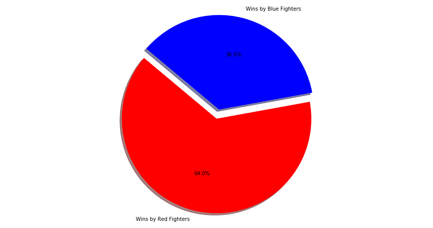

```python
import seaborn as sns
import numpy as np
import matplotlib.pyplot as plt

# Plotting for Number of wins and Fighter colors as UFC puts the favored fighter in the red corners
num_red_wins = 0
num_blue_wins = 0

#iterating through each row to update count of red or blue wins
for i, row in raw_data.iterrows():
    if (row['Winner'] == 1):
        num_red_wins = num_red_wins + 1
    elif (row['Winner'] == 0):
        num_blue_wins = num_blue_wins + 1

labels = 'Wins by Red Fighters', 'Wins by Blue Fighters'
sizes = [num_red_wins, num_blue_wins]
colors = ['red', 'blue']
explode = (0, 0.1)

# Plot
plt.figure(figsize=(15,8))
plt.pie(sizes, explode=explode, labels=labels, colors=colors,autopct='%1.1f%%', shadow=True, startangle=140)

plt.axis('equal')
plt.show()
```

### Distribution of fighter by weight class

Here we break down the fighters category based on 13 weight divisions the UFC set along with the upper weight limit:

- Womens Strawweight - 115 lb (52.1 kg)
- Flyweight -125 lb (56.7 kg)
- Women's Flyweight -125 lb (56.7 kg)
- Bantamweight135 lb (61.2 kg)
- Women's Bantamweight -125 lb (56.7 kg)
- Featherweight-145 lb (65.8 kg)
- Lightweight -155 lb (70.3 kg)
- Super lightweight-165 lb (74.8 kg)
- Welterweight -170 lb (77.1 kg)
- Middleweight -185 lb (83.9 kg)
- Light heavyweight -205 lb (93.0 kg)
- Heavyweight - 265 lb (120.2 kg)
- CatchWeight -Unspecified (not counted)

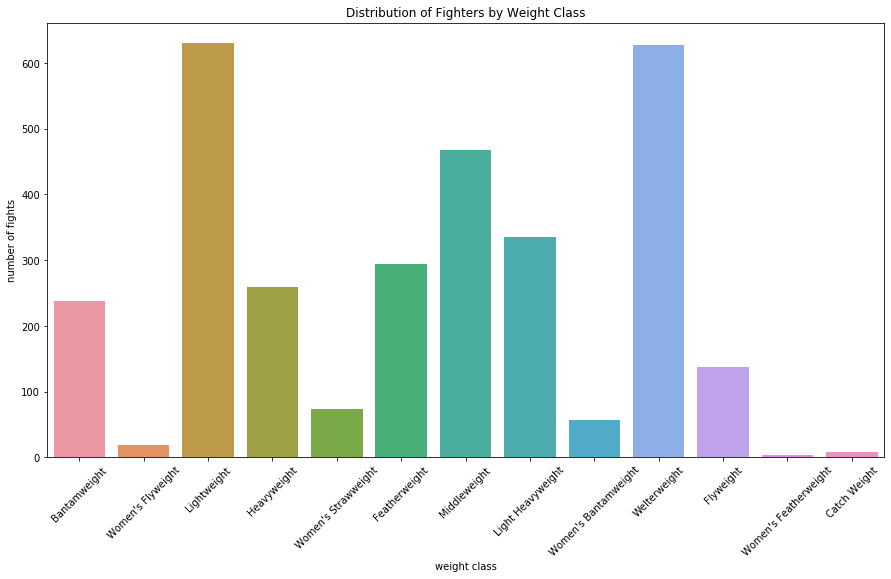

```python
plt.figure(figsize=(15,8))
plt.xticks(rotation=45)

weight_dist = sns.countplot(x=raw_data['weight_class'], data=raw_data)
weight_dist.set(xlabel='weight class', ylabel='number of fights', title='Distribution of Fighters by Weight Class')

weight_dist
```

### Distribution of fighters by gender

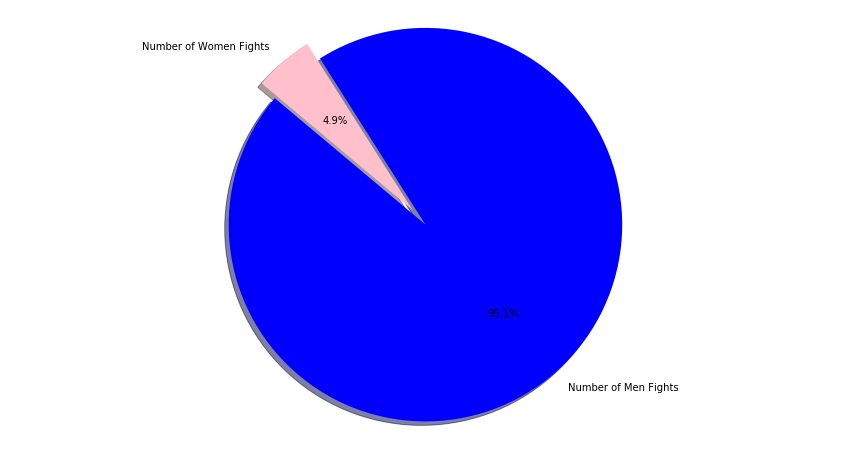

```python
men_fights = 0
women_fights = 0

for i, row in raw_data.iterrows():
    if (row['Gender'] == "M"):
        men_fights = men_fights + 1
    elif (row['Gender'] == "F"):
        women_fights = women_fights + 1

labels = 'Number of Men Fights', 'Number of Women Fights'
sizes = [men_fights, women_fights]
colors = ['blue', 'pink']
explode = (0, 0.1)

# Plot
plt.figure(figsize=(15,8))
plt.pie(sizes, explode=explode, labels=labels, colors=colors,autopct='%1.1f%%', shadow=True, startangle=140)

plt.axis('equal')
plt.show()
```

### Title fights vs. Non-title fights

Title fights are fights in which the title for the division in which the fight is being held for is at stake. We see that only 6.7 percent of the fights are title bouts, these fights are significant because they jmay signify a new title holder of the division and also becuase they are usually the most watched events.

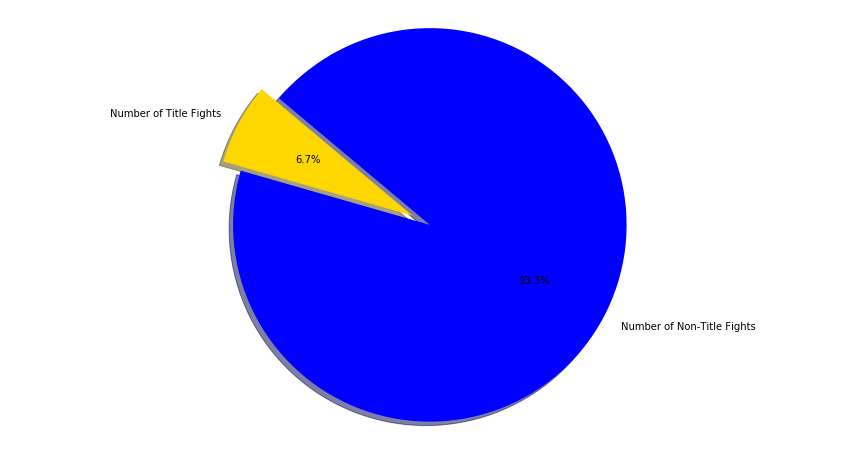

```python
title_fights = 0
normal_fights = 0

for i, row in raw_data.iterrows():
    if (row['title_bout'] == True):
        title_fights = title_fights + 1
    elif (row['title_bout'] == False):
        normal_fights = normal_fights + 1

labels = 'Number of Title Fights', 'Number of Non-Title Fights'
sizes = [title_fights, normal_fights]
colors = ['gold', 'blue']
explode = (0, 0.1)

# Plot
plt.figure(figsize=(15,8))
plt.pie(sizes, explode=explode, labels=labels, colors=colors,autopct='%1.1f%%', shadow=True, startangle=140)

plt.axis('equal')
plt.show()
```

### Distribution of Fighting Stance

In the UFC each fighter also has a prefered stance in which they fight with. Here we break down each of the fighters' chosen stance and how often we see each of the stances during actual fights. The orthodox fighting stance is by far the most popular followed by the Southpaw stance, the switch stance, and the least popular, the open stance.

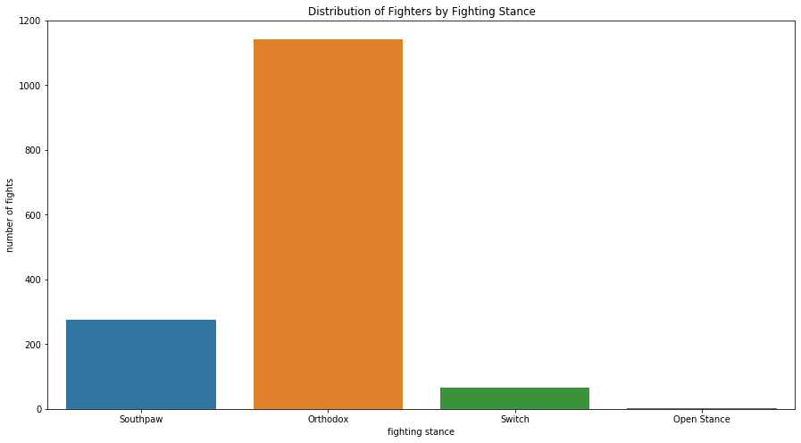

```python
plt.figure(figsize=(15,8))
stance_dist = sns.countplot(x=f_data['Stance'], data=f_data)

stance_dist.set(xlabel='fighting stance', ylabel='number of fights',
                title='Distribution of Fighters by Fighting Stance')

plt.show()
```

### Does a fighters significant strike accuracy affect winning percentage?

Another statistic looked at when matches are decided by judges decisions are significant strikes landed. These strikes differ from those counted in the total strikes landed because significant strikes are those which are landed from a distance when either in the clinch (when standing) and on the ground. Significant strikes tend to do more damage than regular strikes as the increased distance that the strike is landed from increases the force of the strike and in turn causes more damage to the opposing fighter. We wanted to make a predictive model by measuring the accuracy of a fighters significant strikes, measured as significant strikes landed over atttempted, and plotting that against their win percentage.

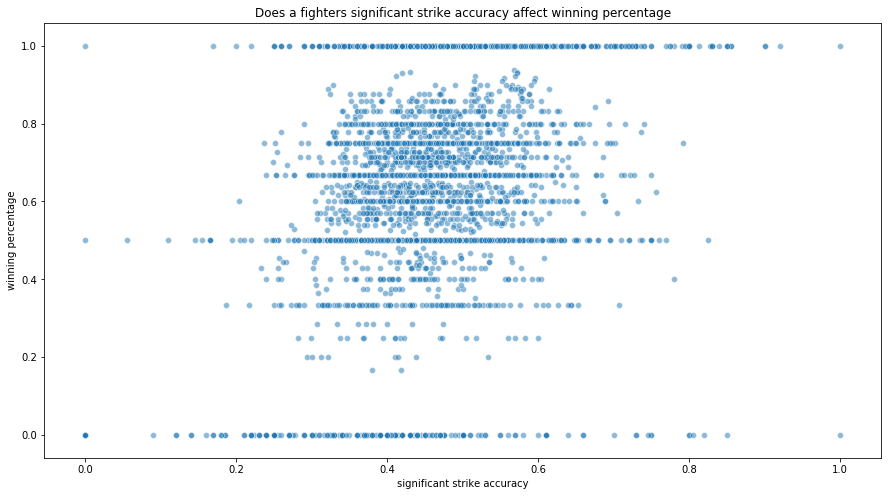

```python
plt.figure(figsize=(15,8))
ax = sns.scatterplot(x="R_avg_SIG_STR_pct", y="R_win_pct", data=raw_data, alpha = 0.5)
ax.set(xlabel='significant strike accuracy', ylabel='winning percentage',
       title='Does a fighters significant strike accuracy affect winning percentage')

plt.show()
```

### How does momentum affect the outcome of a fight?

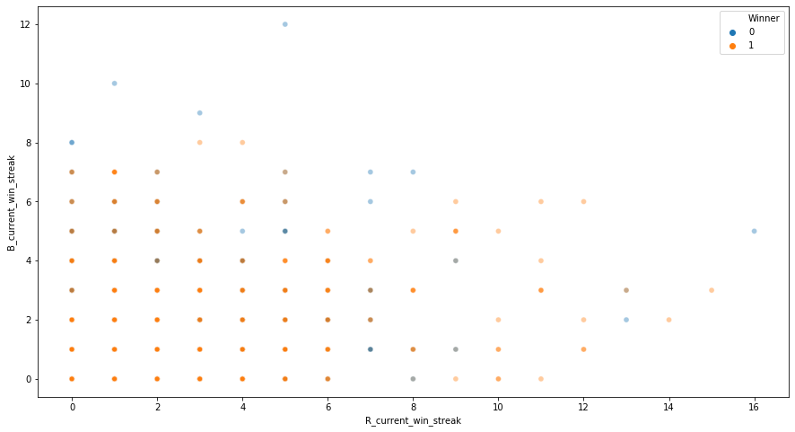

```python
plt.figure(figsize=(15,8))
ax = sns.scatterplot(x='R_current_win_streak', y='B_current_win_streak', hue='Winner', data=raw_data, alpha = 0.4)
```

## Machine Learning & Analysis

### Cleaning the dataset for logistic regression

In this next section, we will perform logistic regression algorithms to predict winner of UFC fights winner is a binary variable:

- 1: red is the winner of the fight
- 0: blue is the winner of the fight

First, we need to drop the following non-numeric columns: 'R_fighter', 'B_fighter', 'Referee', 'date', 'location', 'title_bout', 'weight_class','R_Stance', 'B_Stance', 'level_0', 'index', 'gender'

```python
#y variable: 1 (red corner winner of fight), 0: (blue corner winner of fight)

#first drop non-numeric columns
#Winner column (predicted variable) is alredy 0,1 encoded

to_remove = [
    'R_fighter', 'B_fighter', 'Referee', 'date', 'location', 'title_bout', 'weight_class',
    'R_Stance', 'B_Stance', 'index', 'Gender'
]

raw_data.drop(to_remove, axis=1, inplace = True)

print(len(list(raw_data.columns)))
```

```
58
```

### Feature selection

After removing non-numeric columns, our dataset still has 58 features. We will use feature selection to select the 20 most important features to improve the accuracy of our training algorithms.

To help in feature selection, we will implement [Recursive Feaeture Elimination](https://scikit-learn.org/stable/modules/generated/sklearn.feature_selection.RFE.html). The basic concept is to recursively construct a model, removing either the worst or best feature at each step. The newton-cg method is used for the solver.

The RFE method has selected the following 20 most important features out of the dataset: 'B_current_win_streak', 'B_avg_SIG_STR_pct', 'B_avg_SUB_ATT', 'B_avg_TD_att', 'B_total_title_bouts', 'B_win_by_KO/TKO', 'B_win_by_Submission', 'B_wins', 'R_avg_SIG_STR_att', 'R_avg_SIG_STR_landed', 'R_avg_TD_landed', 'R_avg_TD_pct', 'R_avg_TOTAL_STR_att', 'R_avg_TOTAL_STR_landed', 'R_losses', 'R_total_title_bouts', 'R_age', 'B_win_by_Decision', 'B_avg_TOTAL_STR_pct', 'R_avg_TOTAL_STR_pct'

```python
#feature selection
from sklearn.feature_selection import RFE
from sklearn.linear_model import LogisticRegression
from sklearn import metrics
from sklearn.model_selection import train_test_split

#retrieve dependent(y) and independent (X) column(s) from the dataframe
y = raw_data['Winner']
X = raw_data.drop('Winner',axis=1)

#select 20 most important features
logreg = LogisticRegression(solver = 'newton-cg')
rfe = RFE(logreg, 20)
rfe = rfe.fit(X, y)

mask = rfe.support_
columns = list(raw_data.columns)
columns.remove('Winner')
selected_columns = []

#remove unselected features
for i in range(len(mask)):
    if mask[i]:
        selected_columns.append(columns[i])
```

### Statistical analysis

Now we are left with the following 17 features: 'B_current_win_streak', 'B_avg_SIG_STR_pct', 'B_avg_TD_att', 'B_total_title_bouts', 'B_win_by_Submission', 'B_wins', 'R_avg_SIG_STR_att', 'R_avg_SIG_STR_landed', 'R_avg_TD_landed', 'R_avg_TOTAL_STR_att', 'R_avg_TOTAL_STR_landed', 'R_losses', 'R_total_title_bouts', 'R_age', 'B_win_by_Decision', 'B_avg_TOTAL_STR_pct', 'R_avg_TOTAL_STR_pct

```python
#statistical analysis
import statsmodels.api as sm

#select only the top 20 features (columns)
X = raw_data[selected_columns]

logit_model=sm.Logit(y,X)
result = logit_model.fit()
print(result.summary())

selected_columns.remove('B_avg_SUB_ATT')
selected_columns.remove('R_avg_TD_pct')
selected_columns.remove('B_win_by_KO/TKO')

print(list(selected_columns))
```

```
Optimization terminated successfully.
         Current function value: 0.615980
         Iterations 6
                           Logit Regression Results
==============================================================================
Dep. Variable:                 Winner   No. Observations:                 3151
Model:                          Logit   Df Residuals:                     3131
Method:                           MLE   Df Model:                           19
Date:                Mon, 16 Dec 2019   Pseudo R-squ.:                 0.05746
Time:                        15:47:44   Log-Likelihood:                -1941.0
converged:                       True   LL-Null:                       -2059.3
Covariance Type:            nonrobust   LLR p-value:                 1.527e-39
==========================================================================================
                             coef    std err          z      P>|z|      [0.025      0.975]
------------------------------------------------------------------------------------------
B_current_win_streak      -0.0872      0.030     -2.893      0.004      -0.146      -0.028
B_avg_SIG_STR_pct         -1.5497      0.544     -2.850      0.004      -2.615      -0.484
B_avg_SUB_ATT              0.0448      0.068      0.662      0.508      -0.088       0.177
B_avg_TD_att              -0.0640      0.016     -4.044      0.000      -0.095      -0.033
B_total_title_bouts        0.1300      0.046      2.819      0.005       0.040       0.220
B_win_by_KO/TKO           -0.3231      0.167     -1.937      0.053      -0.650       0.004
B_win_by_Submission       -0.3356      0.166     -2.024      0.043      -0.660      -0.011
B_wins                     0.3462      0.162      2.137      0.033       0.029       0.664
R_avg_SIG_STR_att          0.0734      0.022      3.298      0.001       0.030       0.117
R_avg_SIG_STR_landed      -0.0755      0.025     -2.961      0.003      -0.125      -0.026
R_avg_TD_landed            0.1429      0.049      2.929      0.003       0.047       0.238
R_avg_TD_pct               0.4281      0.233      1.841      0.066      -0.028       0.884
R_avg_TOTAL_STR_att       -0.0696      0.022     -3.131      0.002      -0.113      -0.026
R_avg_TOTAL_STR_landed     0.0673      0.025      2.678      0.007       0.018       0.116
R_losses                  -0.0906      0.020     -4.638      0.000      -0.129      -0.052
R_total_title_bouts        0.0658      0.026      2.565      0.010       0.016       0.116
R_age                     -0.0414      0.009     -4.569      0.000      -0.059      -0.024
B_win_by_Decision         -0.3607      0.165     -2.181      0.029      -0.685      -0.037
B_avg_TOTAL_STR_pct        2.8562      0.494      5.777      0.000       1.887       3.825
R_avg_TOTAL_STR_pct        2.1983      0.501      4.391      0.000       1.217       3.180
==========================================================================================
['B_current_win_streak', 'B_avg_SIG_STR_pct', 'B_avg_TD_att', 'B_total_title_bouts', 'B_win_by_Submission', 'B_wins', 'R_avg_SIG_STR_att', 'R_avg_SIG_STR_landed', 'R_avg_TD_landed', 'R_avg_TOTAL_STR_att', 'R_avg_TOTAL_STR_landed', 'R_losses', 'R_total_title_bouts', 'R_age', 'B_win_by_Decision', 'B_a…
```

### Model Accuracy

```python
from sklearn.metrics import accuracy_score
from sklearn.discriminant_analysis import LinearDiscriminantAnalysis
from sklearn.neighbors import KNeighborsClassifier
from sklearn.model_selection import cross_val_score

#select only selected columns
X = raw_data[selected_columns]

X_train, X_test, y_train, y_test = train_test_split(X, y, test_size=0.3, random_state=0)

logreg = LogisticRegression()
logreg.fit(X_train, y_train)

y_pred = logreg.predict(X_test)

knn = KNeighborsClassifier(n_neighbors=19)
knn_scores = cross_val_score(knn, X, y, cv=10, scoring='accuracy')

lda = LinearDiscriminantAnalysis()
lda_scores = cross_val_score(lda, X, y, cv=10, scoring='accuracy')


print("Sklearn regularized Logistic Regression accuracy: %0.2f" % (metrics.accuracy_score(y_test, y_pred)))
print("K-nearest neighbours classifier accuracy: %0.2f (+/- %0.2f)" % (knn_scores.mean(), knn_scores.std() * 2))
print("Linear Discriminant Analysis (LDA) classifier accuracy: %0.2f (+/- %0.2f)" %
      (lda_scores.mean(), lda_scores.std() * 2))
print()
```

```
Sklearn regularized Logistic Regression accuracy: 0.65
K-nearest neighbours classifier accuracy: 0.61 (+/- 0.05)
Linear Discriminant Analysis (LDA) classifier accuracy: 0.66 (+/- 0.06)
```

Below shows the confusion matrix based on sklearns logistic regression algorithm, this includes correct predictions and incorrect predictions (false negatives and false positives). The logistic regression algorithm had an accuracy of 0.653276955602537 and precision of 0.6740467404674046.

```
Accuracy: 0.653276955602537
Precision: 0.6740467404674046
```

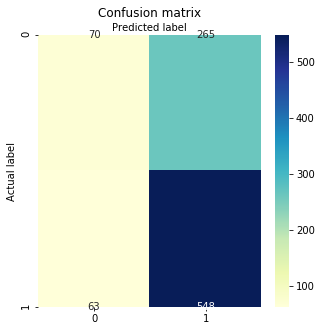

```python
cnf_matrix = metrics.confusion_matrix(y_test, y_pred)

class_names=[0,1] # name  of classes
fig, ax = plt.subplots(figsize=(5,5))
tick_marks = np.arange(len(class_names))
plt.xticks(tick_marks, class_names)
plt.yticks(tick_marks, class_names)
# create heatmap

sns.heatmap(pd.DataFrame(cnf_matrix), annot=True, cmap="YlGnBu" ,fmt='g')
ax.xaxis.set_label_position("top")
plt.title('Confusion matrix', y=1.1)
plt.ylabel('Actual label')
plt.xlabel('Predicted label')

print("Accuracy:",metrics.accuracy_score(y_test, y_pred))
print("Precision:",metrics.precision_score(y_test, y_pred))
```